# Flexible Damage Functions

Author

James Rising, Sebastian Cadavid Sanchez, Climate Impact Lab

Published

April 30, 2026

## 0.1 Energy: Electricity

Flexible damage function parameters at the Impact Region level.

**Outcome units:** `kWh_per_capita` — kWh per capita, rebased to 2005 baseline (positive = more electricity consumed)

$$D_{it} = (\alpha_i T_t + \beta_i T_t^2) \cdot Y_{it}^{\gamma}$$

where $\gamma$ is the income elasticity (fitted globally), $\alpha_i$ is the linear coefficient, and $\beta_i$ is the quadratic coefficient.

# 1 Global Estimation

## 1.1 Income Elasticity Estimation

The income elasticity $\gamma$ is estimated using a fixed-effects regression:

$$y_{it} = \gamma \cdot \log(Y_{it}) + \mu_{g(i,T)} + \nu_t + \varepsilon_{it}$$

where $\mu_{g(i,T)}$ are region-by-temperature-bin fixed effects and $\nu_t$ are year fixed effects.

Table 1: Income Elasticity (Gamma) Estimation Results

| Statistic | Value |
| --- | --- |
| Income elasticity ($\gamma$) | 0.3981 |
| Standard error | 2.43e-02 |
| 95% CI | [0.3504, 0.4458] |
| R-squared | 0.9100 |
| Observations | 16,638,984 |
| Regions | 24,326 |
| Gamma quantiles | 19 |

# 2 Parameter Distributions

## 2.1 8-Panel Summary

Row 1: gamma, alpha, beta, rsqr1. Row 2: rho, zeta, eta, rsqr2.

```
Using median gamma: 0.398139, 24,326 rows (of 462,194 total)
```

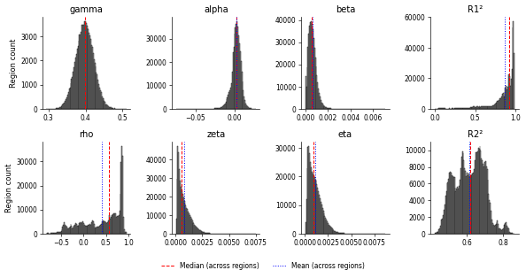

Figure 1: Distribution of Regional Parameters

## 2.2 Projection Equation and Parameter Definitions

The estimated parameters are used to project damages via Monte Carlo sampling:

$$D_{it}^k = (\hat{\alpha}_{ik} T_t + \hat{\beta}_{ik} T_t^2) Y_{it}^{\hat{\gamma}_k} + \hat{\theta}_{ik} T_t Y_{it}^{\hat{\gamma}_k} + \hat{\phi}_{it}^k$$

where $k$ indexes the Monte Carlo draw. The parameters in each row of the output CSV control distinct components of this equation:

- **gamma**: income elasticity $\hat{\gamma}_k$, one of 19 quantile values drawn from $N(\hat{\gamma}, SE(\hat{\gamma}))$
- **alpha, beta**: linear and quadratic temperature coefficients; $\hat{\alpha}_{ik}$ and $\hat{\beta}_{ik}$ are drawn from the joint normal defined by the VCV below
- **sigma11, sigma12, sigma22**: variance-covariance matrix of $(\alpha, \beta)$, used for joint uncertainty sampling
- **rho**: correlation between regional and global polynomial residuals $\rho_i$, used to maintain spatial covariance across regions in Monte Carlo draws
- **zeta**: temperature-dependent error scale $\zeta_{ik}$; the run-specific error term $\hat{\theta}_{ik}$ is drawn from $N(0, \zeta_{ik})$
- **eta**: residual noise standard deviation $\eta_{ik}$; the annual noise $\hat{\phi}_{it}^k$ is drawn from $N(0, \eta_{ik})$
- **rsqr1, rsqr2**: polynomial fit quality and error model fit, respectively

## 2.3 Summary Statistics

Table 2: Regional Parameter Summary

| Parameter | Mean | Median | Std | Min | Max | N |
| --- | --- | --- | --- | --- | --- | --- |
| alpha | 0.002311 | 0.002857 | 0.005941 | -0.04887 | 0.0179 | 24,326 |
| beta | 0.0006114 | 0.0006119 | 0.0003133 | 0 | 0.004717 | 24,326 |
| rho | 0.4191 | 0.5722 | 0.437 | -0.8196 | 0.9536 | 24,326 |
| zeta | 0.0007552 | 0.0006196 | 0.0005521 | 5.71e-05 | 0.005242 | 24,326 |
| eta | 0.001092 | 0.0009834 | 0.0006736 | 9.182e-05 | 0.007467 | 24,326 |
| rsqr1 | 0.8622 | 0.9199 | 0.1635 | 0.0008368 | 0.989 | 24,326 |
| rsqr2 | 0.6149 | 0.6178 | 0.08112 | 0.4233 | 0.8629 | 24,326 |

# 3 Spaghetti Curves

Regional damage function curves showing D(T) = αT + βT² for sampled regions.

[interactive chart not shown]

Figure 2: Regional Damage Functions

# 4 Zero Crossings

The zero crossing (extremum) of the parabola occurs at $T^* = -\alpha / (2\beta)$.

Table 3: Zero Crossing Statistics

| Category | Count | Percentage |
| --- | --- | --- |
| β = 0 (no crossing) | 534 | 2.2% |
| T > 20°C (beyond graph) | 11 | 0.0% |
| T < 0°C (negative crossing) | 16667 | 68.5% |
| Valid crossings (0-20°C) | 7114 | 29.2% |

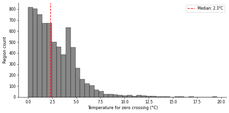

Figure 3: Distribution of Zero Crossing Temperatures

# 5 Slope Analysis

Maximum slope between 0 and 10°C: $\frac{dM}{dT} = \alpha + 2\beta T$

The maximum occurs at either T=0 or T=10 (endpoints of interval).

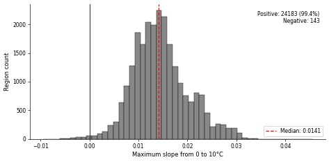

Figure 4: Distribution of Maximum Slopes (0-10°C)

*Convexity analysis omitted (beta constraint active).*

# 6 R-squared Analysis

## 6.1 Polynomial Fit Quality (rsqr1)

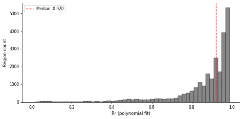

Figure 5: Regional Fit Quality (R-squared)

## 6.2 Error Model R-squared (rsqr2) Quantiles

Table 4: rsqr2 Quantiles

| 0% (Min) | 25% | 50% (Median) | 75% | 100% (Max) |
| --- | --- | --- | --- | --- |
| 0.4233 | 0.5515 | 0.6178 | 0.6770 | 0.8629 |

# 7 Modelled Variance

Modelled variance statistic: $1 - \frac{\sum_i \eta_i^2}{\sum_i D_i^2}$

Table 5: Modelled Variance Statistics

| Statistic | Value |
| --- | --- |
| Modelled variance | 0.9961 |
| Sum(η²) | 0.0400 |
| Sum(D²) at T=3.0°C | 10.2992 |
| N regions | 24,326 |

# 8 Best- and Worst-Fitting Regions

The 3 worst- and 3 best-fitting regions by R-squared, with raw simulation data overlaid on the fitted polynomial curve. **Red rows = worst fits**, **green rows = best fits**.

Table 6: Best- and worst-fitting regions

Top 3 best fit (R²) Top 3 worst fit (R²)

| Region | α | β | η | R² |
| --- | --- | --- | --- | --- |
| ARE.1 | 0.0131 | 5.25e-4 | 0.00102 | 0.989 |
| ARG.17.399 | 0.00896 | 7.02e-4 | 8.11e-4 | 0.989 |
| ARE.5 | 0.00968 | 6.01e-4 | 8.41e-4 | 0.989 |
| AFG.23 | -2.02e-4 | 4.80e-5 | 6.02e-4 | 0.00376 |
| AFG.31.R7533cfa7af80b230 | -4.64e-4 | 1.05e-4 | 5.69e-4 | 0.019 |
| AFG.30.303 | -2.20e-4 | 7.64e-5 | 5.63e-4 | 0.0253 |

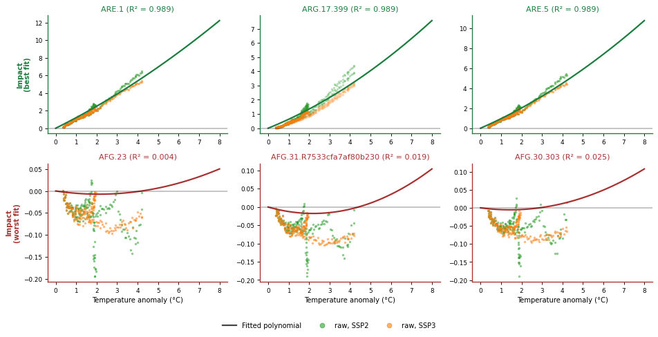

# 9 Regional Parameter Maps

Maps of key parameters at the **impact region** level. Red = negative (damage increases with T), Blue = positive.

## 9.1 Alpha (Linear Coefficient)

Alpha ($\alpha$) represents the linear sensitivity to temperature. Regions with negative alpha experience damage that increases with the first degree of warming.

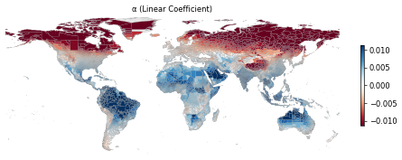

Figure 7: α (linear coefficient)

## 9.2 Beta (Quadratic Coefficient)

Beta ($\beta$) represents the curvature of the damage function.

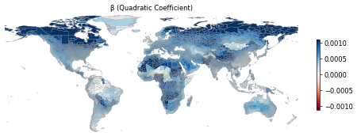

Figure 8: β (quadratic coefficient)

## 9.3 R-squared (Fit Quality)

$R^2$ measures the polynomial fit quality. Higher values indicate that the quadratic form captures more of the variance in the data.

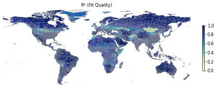

Figure 9: R² (stage 1 fit quality)

# 10 F2: Flex vs Raw Comparison

Comparison of flexible damage function predictions against raw simulation means.

For each scenario (RCP × SSP × Model), we compute at the final year:

- **Flex predicted**: $(\alpha \cdot T + \beta \cdot T^2) \cdot Y^\gamma$
- **Raw actual**: The outcome variable (y) from the source data

**Year 2099**: 195,024 rows

**rcp45**

**SSP2**

**high**

**Correlation:** 0.9773 | **RMSE:** 0.236333 | **Sign agreement:** 96.2%

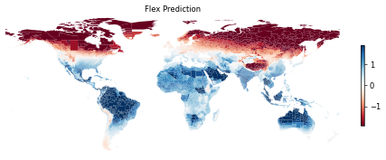

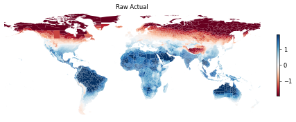

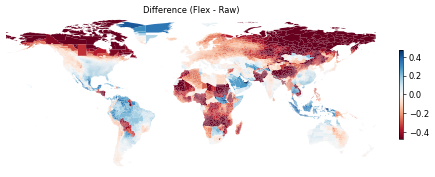

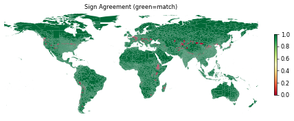

[interactive chart not shown]

Top 5 best predicted Top 5 worst predicted

Year 2099 · T<sub>mean</sub> across these regions: 1.96°C

| Region | Raw | Flex | Residual |
| --- | --- | --- | --- |
| AUS.10.1203 | 0.294 | 0.294 | 8.91e-6 |
| IND.7.116.358 | 1.66 | 1.66 | -1.36e-5 |
| MEX.26.1357 | 0.789 | 0.789 | 2.67e-5 |
| UKR.20.472 | 0.0692 | 0.0692 | 2.81e-5 |
| COL.2.R4ccf3abfa68e6d6e | 1 | 1 | -3.20e-5 |
| CAN.6.98.2246 | -4.33 | -6.08 | -1.75 |
| CAN.6.98.2241 | -4.3 | -5.8 | -1.5 |
| CAN.8.118.2364 | -4.14 | -5.54 | -1.4 |
| CAN.8.117.2359 | -6 | -7.4 | -1.4 |
| CAN.11.259.4265 | -3.72 | -5.09 | -1.38 |

**low**

**Correlation:** 0.9857 | **RMSE:** 0.188225 | **Sign agreement:** 97.2%

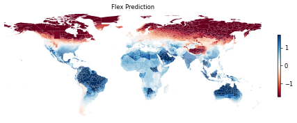

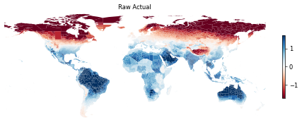

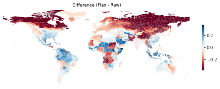

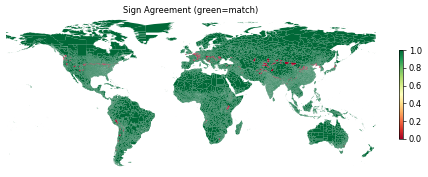

[interactive chart not shown]

Top 5 best predicted Top 5 worst predicted

Year 2099 · T<sub>mean</sub> across these regions: 1.96°C

| Region | Raw | Flex | Residual |
| --- | --- | --- | --- |
| GHA.1.1 | 0.603 | 0.603 | 7.13e-6 |
| ZAF.5.R489b241f2ba70f8c | 0.459 | 0.459 | -3.17e-5 |
| BDI.7 | 0.0083 | 0.00826 | -4.04e-5 |
| AUS.7.965 | 0.717 | 0.717 | 4.14e-5 |
| IND.26.396.1565 | 1.46 | 1.46 | -4.42e-5 |
| CAN.6.98.2246 | -4.42 | -6.13 | -1.71 |
| RUS.65.1741.1858 | -5.33 | -6.78 | -1.46 |
| CAN.6.98.2241 | -4.39 | -5.84 | -1.45 |
| USA.2.84 | -4.21 | -5.57 | -1.37 |
| CAN.8.118.2364 | -4.23 | -5.59 | -1.36 |

**SSP3**

**high**

**Correlation:** 0.9880 | **RMSE:** 0.194616 | **Sign agreement:** 97.4%

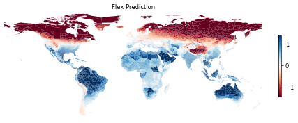

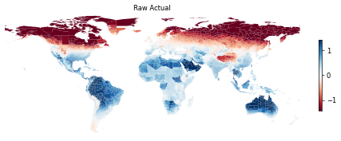

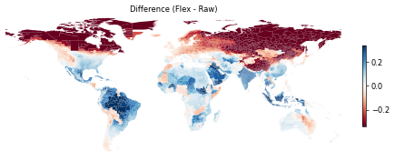

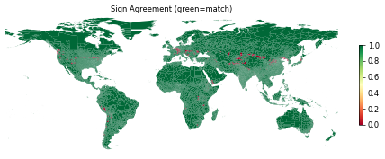

[interactive chart not shown]

Top 5 best predicted Top 5 worst predicted

Year 2099 · T<sub>mean</sub> across these regions: 1.96°C

| Region | Raw | Flex | Residual |
| --- | --- | --- | --- |
| CIV.1.2 | 0.763 | 0.763 | 6.02e-7 |
| AUS.10.1201 | 0.248 | 0.248 | 1.34e-6 |
| AUS.10.1200 | 0.248 | 0.248 | -8.31e-6 |
| JPN.11.R8e539386cb91bf0a | 0.376 | 0.376 | -2.41e-5 |
| ITA.6.26 | 0.34 | 0.34 | -4.18e-5 |
| CAN.6.98.2246 | -4.45 | -6.18 | -1.73 |
| RUS.65.1741.1858 | -4.73 | -6.23 | -1.5 |
| CAN.6.98.2241 | -4.43 | -5.89 | -1.47 |
| CAN.8.118.2364 | -4.26 | -5.64 | -1.38 |
| CAN.11.259.4265 | -3.82 | -5.18 | -1.36 |

**low**

**Correlation:** 0.9895 | **RMSE:** 0.189045 | **Sign agreement:** 96.5%

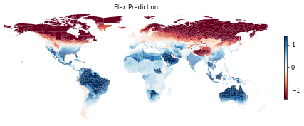

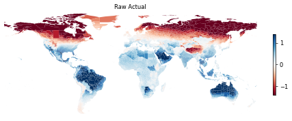

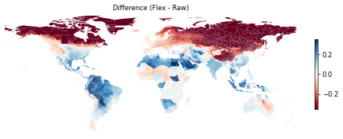

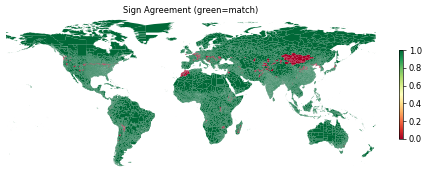

[interactive chart not shown]

Top 5 best predicted Top 5 worst predicted

Year 2099 · T<sub>mean</sub> across these regions: 1.96°C

| Region | Raw | Flex | Residual |
| --- | --- | --- | --- |
| USA.5.234 | 0.909 | 0.909 | -8.02e-6 |
| MEX.15.Rb5cda7e6656a6a82 | 0.177 | 0.177 | -8.17e-6 |
| NZL.R5a1c2dedd14afe54 | 0.0504 | 0.0504 | -1.72e-5 |
| SDN.1.1.5.6 | 0.437 | 0.437 | 1.74e-5 |
| BOL.4.33.100 | -0.0726 | -0.0726 | 2.65e-5 |
| CAN.6.98.2246 | -3.71 | -5.41 | -1.7 |
| RUS.65.1741.1858 | -4.74 | -6.33 | -1.59 |
| CAN.6.98.2241 | -3.69 | -5.16 | -1.47 |
| RUS.5.108.108 | -4.31 | -5.75 | -1.44 |
| CAN.8.117.2359 | -5.15 | -6.58 | -1.43 |

**rcp85**

**SSP2**

**high**

**Correlation:** 0.9860 | **RMSE:** 0.366767 | **Sign agreement:** 97.8%

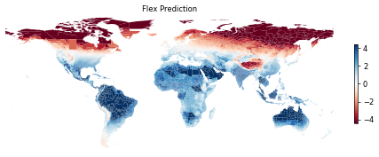

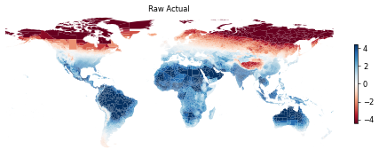

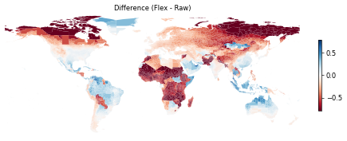

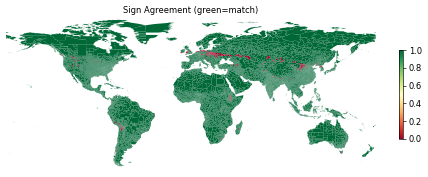

[interactive chart not shown]

Top 5 best predicted Top 5 worst predicted

Year 2099 · T<sub>mean</sub> across these regions: 4.20°C

| Region | Raw | Flex | Residual |
| --- | --- | --- | --- |
| USA.11.514 | 2.63 | 2.63 | 7.75e-6 |
| AUS.10.1225 | 1.41 | 1.41 | -1.06e-5 |
| USA.25.1467 | 2.83 | 2.83 | -2.61e-5 |
| BRA.21.3994.Rada98188ba5830af | 2.11 | 2.11 | -4.54e-5 |
| CAN.9.157.2763 | -0.325 | -0.324 | 4.70e-5 |
| CAN.6.98.2246 | -8.56 | -10.4 | -1.8 |
| CAN.8.117.2359 | -11.2 | -12.9 | -1.66 |
| CAN.6.98.2241 | -8.26 | -9.91 | -1.65 |
| CAN.8.119.2370 | -9.31 | -10.9 | -1.57 |
| CAN.8.119.2371 | -9.73 | -11.2 | -1.52 |

**low**

**Correlation:** 0.9925 | **RMSE:** 0.262355 | **Sign agreement:** 98.2%

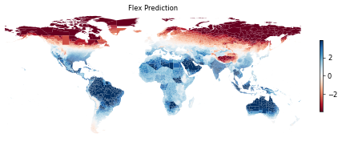

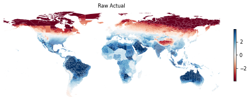

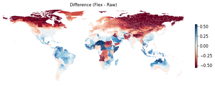

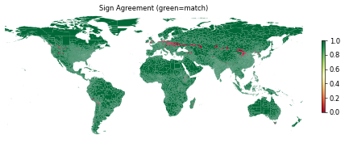

[interactive chart not shown]

Top 5 best predicted Top 5 worst predicted